### Analysis 2: One Categorical Variable

#### Analyst:Daniel Gurwah

When first looking at this variable, there were some rows where the genre was "". First, I replaced these rows with NA. However, this led to me realizing that these rows also were rows that had no game name. When looking at the frequency table it’s obvious that action games were clearly the highest games sold and played. They take up just over 20% of the data points. However, after plotting this variable I realized that sports games were also larger than most. The other game genres are about all within 1000 range of each other.

```r
#clearing the no genre rows in the NA
vgs$Genre[vgs$Genre %in% c("")]<- NA
#creating the frequency table
freq_genre <- table(vgs$Genre)
#creating the relative frequency table
rel_freq_genre <- table(vgs$Genre)/nrow(vgs)
#plotting and displaying the data
freq_genre %>% knitr::kable()
```

| Var1 | Freq |
| --- | --- |
| Action | 3370 |
| Adventure | 1303 |
| Fighting | 849 |
| Misc | 1750 |
| Platform | 888 |
| Puzzle | 580 |
| Racing | 1249 |
| Role-Playing | 1500 |
| Shooter | 1323 |
| Simulation | 874 |
| Sports | 2348 |
| Strategy | 683 |

```r
rel_freq_genre%>% knitr::kable()
```

| Var1 | Freq |
| --- | --- |
| Action | 0.2015912 |
| Adventure | 0.0779446 |
| Fighting | 0.0507866 |
| Misc | 0.1046839 |
| Platform | 0.0531196 |
| Puzzle | 0.0346952 |
| Racing | 0.0747144 |
| Role-Playing | 0.0897290 |
| Shooter | 0.0791410 |
| Simulation | 0.0522821 |
| Sports | 0.1404558 |
| Strategy | 0.0408566 |

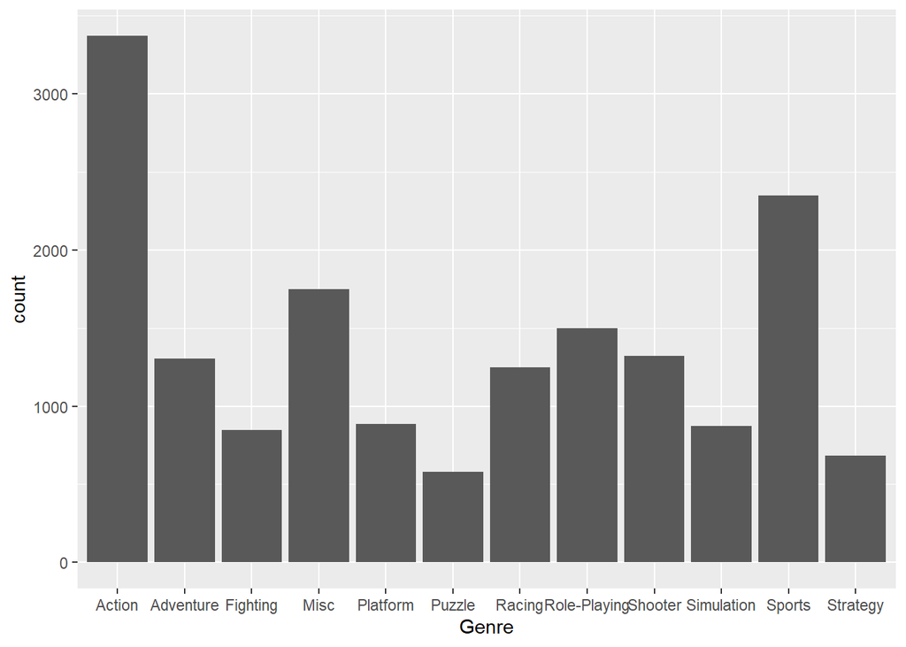

```r
ggplot(data = vgs) + geom_bar(mapping = aes(x = Genre))
```

### Analysis 3: Two Categorical Variables

#### Analyst: Joey Difrancesco

For this analysis I chose Rating and Genre for the categorical variables. Both variables are nominal levels of measurement because we are assigning classification of each variable. For example, the video game belonging to the E rating is classified as E. I would hypothesize a potential association between the two because you can see some genres favor certain ratings. For example, the sports genre is mostly rated either E or NA. I can hypothesize that certain genres are tailored more towards certain ratings or certain target audiences. Based on the two way table and the stacked bar chart, it looks like there is an association present. If the distribution of ratings throughout each genre was more spread out, meaning less zeros and less heavy leaning ratings, then I don’t believe there would be an association, yet that’s not the case.

```r
twoway <- addmargins(table(vgs$Rating, vgs$Genre))
twoway %>% knitr::kable()
```

|  | Action | Adventure | Fighting | Misc | Platform | Puzzle | Racing | Role-Playing | Shooter | Simulation | Sports | Strategy | Sum |
| --- | --- | --- | --- | --- | --- | --- | --- | --- | --- | --- | --- | --- | --- |
| AO | 1 | 0 | 0 | 0 | 0 | 0 | 0 | 0 | 0 | 0 | 0 | 0 | 1 |
| E | 416 | 162 | 8 | 457 | 358 | 289 | 585 | 84 | 48 | 326 | 1188 | 70 | 3991 |
| E10+ | 481 | 68 | 19 | 167 | 144 | 43 | 96 | 111 | 58 | 48 | 107 | 78 | 1420 |
| EC | 1 | 2 | 0 | 5 | 0 | 0 | 0 | 0 | 0 | 0 | 0 | 0 | 8 |
| K-A | 0 | 0 | 0 | 1 | 0 | 0 | 0 | 0 | 0 | 0 | 0 | 2 | 3 |
| M | 608 | 99 | 49 | 13 | 3 | 0 | 18 | 162 | 565 | 5 | 16 | 25 | 1563 |
| RP | 0 | 0 | 0 | 0 | 0 | 0 | 1 | 0 | 0 | 0 | 0 | 2 | 3 |
| T | 681 | 115 | 362 | 239 | 64 | 10 | 172 | 420 | 348 | 190 | 198 | 162 | 2961 |
| Sum | 2188 | 446 | 438 | 882 | 569 | 342 | 872 | 777 | 1019 | 569 | 1509 | 339 | 9950 |

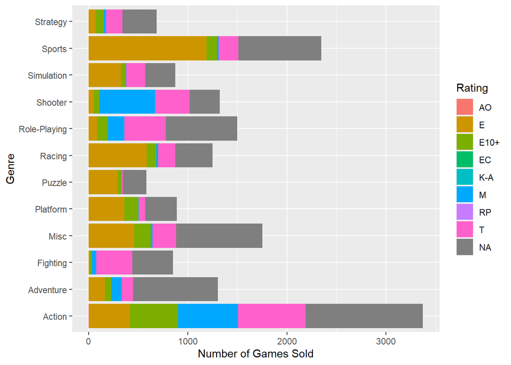

```r
ggplot(vgs, aes(y = Genre)) + geom_bar(aes(fill = Rating), position = position_stack(reverse = TRUE)) + ylab('Genre') +xlab('Number of Games Sold')
```